# 数据整合和辅助建模技术（1）

林荟 (杜邦先锋商业数据科学家)

2016-06-08

# 前情提要

1. 什么是数据科学家
   - 澄清定义：行业现状，分布，教育技能要求等
   - http://www.xueqing.tv/course/55
2. 数据预处理
   - 数据分析的一般流程：问题到数据，数据到信息，信息到价值
   - 数据预处理
   - http://www.xueqing.tv/course/66 或者 http://scientistcafe.com
3. 补充
   - 相关文献
   - 做一个知道在哪里划线的人
   - 问题和反馈: longqiman@gmail.com

# 介绍

- 幻灯片 & R代码：http://scientistcafe.com
- 数据整合
  - `psych`包中的`describle()`函数
  - `apply()`、`lapply()`和`sapply()`
  - `plyr`包中的`ddply()`函数
  - `dplyr`包
  - *`reshape2`包
  - *`tidyr`包
- 建模技术
  - 有监督 v.s 无监督
  - 误差极其来源和影响
  - *数据划分和再抽样
  - *评估模型表现

# 服装消费者数据

1. 人口统计学变量
   - 年龄（age）
   - 性别（gender）
   - 有房还是租房（house）
2. 消费者行为变量
   - 2015年实体店购买该品牌服装花销（store_exp）
   - 2015年在线购买该品牌服装花销（online_exp）
   - 2015年实体店交易次数（store_trans）
   - 2015年在线交易次数（online_trans）
3. 客户认知问卷调查

# 服装消费者数据

（Q1）：我喜欢买不同品牌的服装，比较它们  
（Q2）：我喜欢买同一个品牌的服装  
（Q3）：品牌的知名度对我来说非常重要  
（Q4）：服装质量对我来说非常重要  
（Q5）：服装风格我喜欢的风格  
（Q6）：我喜欢在实体店购买  
（Q7）：我喜欢在网上购买  
（Q8）：价格对我来说很重要  
（Q9）：我喜欢不同风格的衣服  
（Q10）：我喜欢自己挑选服装，不需要周围人的建议

- 1（非常不同意）, 2（有点不同意）, 3（中立/不知道）, 4（有点同意）, 5（非常同意）

# 数据整合

- `psych`包中的`describle()`函数
- `base`包中的 `apply()`、`lapply()`和`sapply()`
  1. 依次对某一对象的某一部分重复应用一个指定的函数
  2. 返回对象不同
  3. 有针对性的得到想要的输出结果
- `plyr`包中的`ddply()`函数
  1. `summarize`
  2. `transform`
  3. `subset`

# 数据整合

- `dplyr`包: `ddply()`等函数的强化版，专门处理数据框（dataframe）对象，大幅提高了速度, 并且提供了更稳健的与其它数据库对象间的接口
1. 数据框显示
2. 数据截选（按行／列）
3. 数据总结
4. 生成新变量
5. 合并数据集

# 有监督 v.s 无监督学习

自变量和应变量的关系为：

$$\mathbf{y}=f(\mathbf{X})+\mathbf{\epsilon}$$

有监督和无监督建模技术用上面的符号语言表达就是：

1. 无监督建模：探索$\mathbf{X}$中的自变量之间的关系
2. 有监督建模：估计$\mathbf{y}$和$\mathbf{X}$之间的关系 $f(\cdot)$

# 误差及其来源 - 系统误差和随机误差

- $f$的估计$\hat{f}$
- $\mathbf{y}$的预测 $\hat{\mathbf{y}}=\hat{f}(\mathbf{X})$
- 预测的误差分成两部分，系统误差和随机误差：

$$E(\mathbf{y}-\hat{\mathbf{y}})^{2}=E[f(\mathbf{X})+\mathbf{\epsilon}-\hat{f}(\mathbf{X})]^{2}=\underset{\text{(1)}}{\underbrace{[f(\mathbf{X})-\hat{f}(\mathbf{X})]^{2}}}+\underset{\text{(2)}}{\underbrace{Var(\mathbf{\epsilon})}}$$

（1）系统误差，能通过改进模型得到提高；  
（2）随机误差，当前数据无法解释的部分，无法通过建立更复杂的模型来改进。

# 误差及其来源 - 应变量误差

- 反映在随机误差（$\mathbf{\epsilon}$）中
- 使得均方根误差（RMSE）和$R^2$有相应的上下限
- 假设我们希望利用消费记录变量建立关于消费者收入的预测模型:
- 在应变量年收入（`income`）上添加不同程度的噪音（均方根误差的0到3倍）：

$$RMSE \times (0.0, 0.5, 1.0, 1.5, 2.0, 2.5, 3.0)$$

- 对以下模型的影响：一般线性回归，偏最小二乘回归，多元自适应回归样条，支持向量机（核函数是径向基函数），随机森林

# 误差及其来源 - 应变量误差

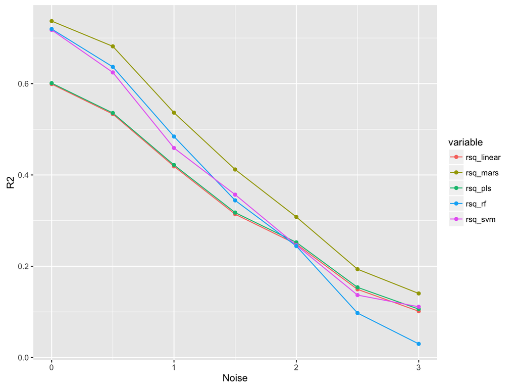

# 误差及其来源 - 自变量误差

- 自变量观测中的随机性产生的影响取决于如下几个因素：
  1. 随机性的强度
  2. 相应因变量在模型中的重要性
  3. 使用模型的类别
- 在自变量`online_exp`和上添加如下不同程度的噪音（该变量观测标准差的0到3倍）

$$\sigma_{0} \times (0.0, 0.5, 1.0, 1.5, 2.0, 2.5, 3.0)$$

- 检查噪音强度对复杂度不同的模型拟合$R^2$的影响
- 一般线性回归，偏最小二乘回归，多元自适应回归样条，支持向量机（核函数是径向基函数），随机森林

# 误差及其来源 - 自变量误差

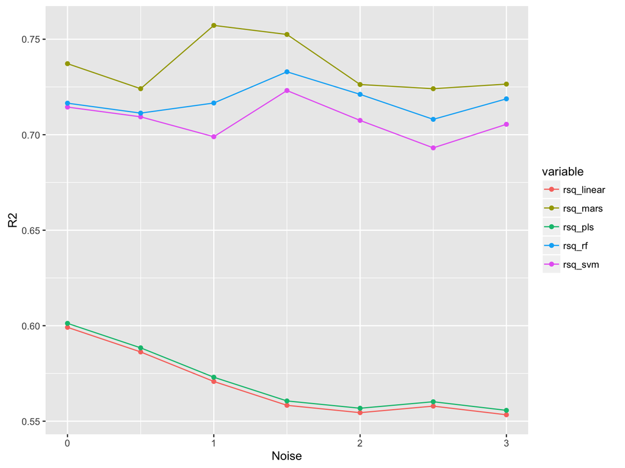

# 数据整合和辅助建模技术（2）

- 数据整形
  - `reshape2`包
  - `tidyr`包
- 建模技术
  - 数据划分
    - 按照结果变量划分数据
    - 按照自变量划分
    - 按时间序列划分
  - 数据重抽样
    - k折交叉验证
    - 重复训练/测试集划分
    - Bootstrap
  - 评估模型表现
    - 回归模型
    - 分类模型

# 参考文献（数据预处理）

- Ton de Waal, Sander Scholtus, Jeroen Pannekoek. 2011. Handbook of Statistical Data Editing and Imputation. John Wiley & Sons.
- Jolliffe, I.T. 2002. Principla Component Analysis. 2nd ed. New York: Springer.
- Geladi P, Kowalski B. 1986. “Partial Least-Squares Regression: A Tutorial.” Analytica Chimica Acta, no. 185: 1–17.
- Mulaik, S.A. 2009. Foundations of Factor Analysis. 2ND ed. Boca Raton: Chapman&Hall/CRC.
- Box G, Cox D. 1964. “An Analysis of Transformations.” Journal of the Royal Statistical Society Series B (Methodological): 211–52.
- Iglewicz, Boris, and David Hoaglin. 1993. “How to Detect and Handle Outliers.” The ASQC Basic References in Quality Control: Statistical Techniques 16.
- Serneels S, Espen PV, Nolf ED. 2006. “Spatial Sign Pre-Processing: A Simple Way to Impart Moderate Robustness to Multivariate Estimators.” Journal of Chemical Information and Modeling 46 (3): 1402–9.
- Kjell Johnston, Max Kuhn &. 2013. Applied Predictive Modeling. Springer.

# 参考文献（数据整合）

- RStudio Cheat Sheet